# 병합정렬(Merge Sort)

### 일단 정확히 반으로 나누고 나중에 정렬한다

- 시간복잡도 O(N^2) : 선택정렬, 버블정렬, 삽입정렬 알고리즘
- 퀵정렬 : 평균 시간복잡도 O(N* logN) but 피벗이 편향되게 분할할 경우 O(N^2)가 될 수 있음
- 병합정렬 -> O(N* logN) 정확히 반절씩 나눈다는 점에서 최악의 경우도 보장

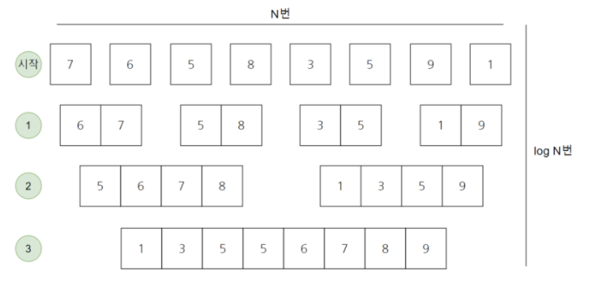

```python
def mergesort2 (S, left, right):
    if(left< right):
        mid = (left + right) // 2
        mergesort2(S, left, mid)
        mergesort2(S, mid+1, right)
        merge2(S,left,right)

def merge2(S, left, right):
    U=[]
    i=left
    mid = (left + right) // 2
    j=mid + 1
    while(i<=mid and j <=right):
        if (S[i]<S[j]):
            U.append(S[i])
            i+=1
        else:
            U.append(S[j])
            j+=1
    if(i<=mid):
        U += S[i:mid+1]
    else:
        U+= S[j:right+1]

    for k in range(left, right+1):
        S[k]= U[k-left]

    print(U)

S=[4, 5, 6, 7, 1, 3, 9, 8]
print("Before:", S, "\n")
mergesort2(S,0,len(S)-1)
print()
print("After:", S)
```

```
Before: [4, 5, 6, 7, 1, 3, 9, 8]

[4, 5]
[6, 7]
[4, 5, 6, 7]
[1, 3]
[8, 9]
[1, 3, 8, 9]
[1, 3, 4, 5, 6, 7, 8, 9]

After: [1, 3, 4, 5, 6, 7, 8, 9]
```

```python
a=[1,3,4,5,6,7]
a +=[9,8]
print(a)
```

```
[1, 3, 4, 5, 6, 7, 9, 8]
```

# 힙 정렬(heap sort)

### 힙: 위쪽부터 일정하게 부모의 값 >= 자식의 값이 항상 성립하는 조건을 만족하는 완전 이진트리

#### 이진트리 : 모든 노드의 자식노드가 2개 이하인 트리구조

#### - 선택정렬을 응용한 알고리즘

### - 각각의 원소 : 노드/ 노드의 상하관계 : 부모노드, 자식노드, 형제노드

#### - 힙에서는 형제의 대소관계는 정해져 있지 않음 -> 부분순서트리

### - 루트(가장 위에 위치한 노드), 리프(자식이 없는 노드)

#### 최소 힙: 부모 노드의 키값이 자식 노드의 키값보다 항상 작은 힙

#### 최대 힙: 부모 노드의 키값이 자식 노드의 키값보다 항상 큰 힙

[figure not shown]

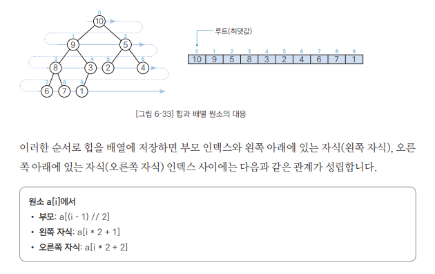

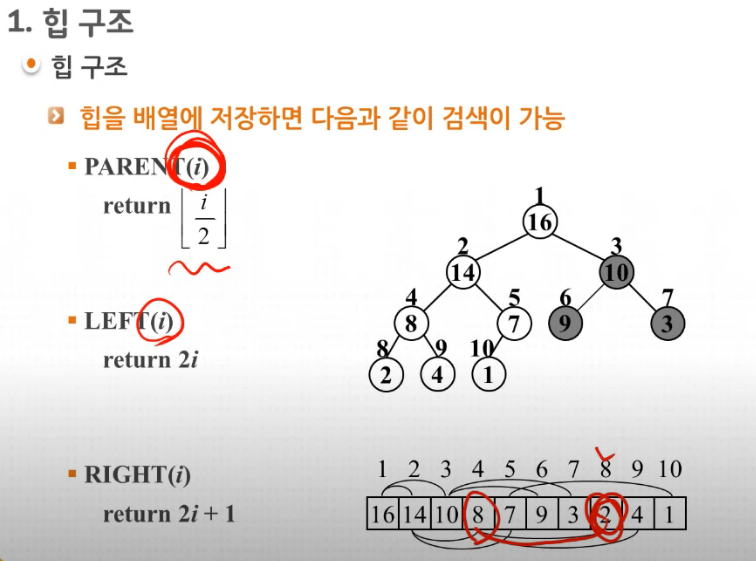

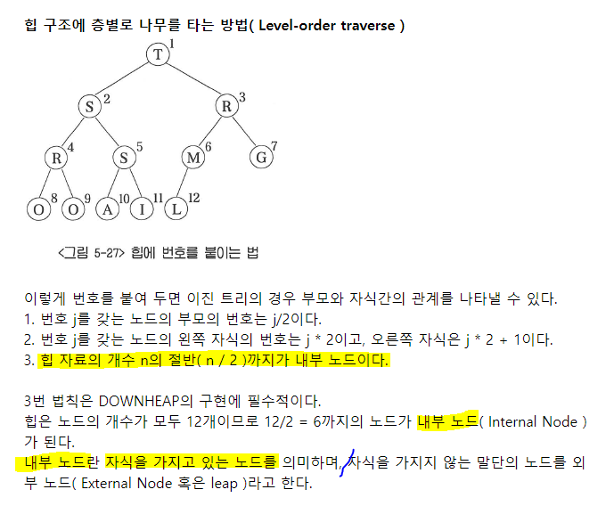

### 루트를 삭제하고 다시 힙으로 만들기 위한 과정

1. 루트를 꺼낸다.
2. 마지막 원소(가장 하단의 오른쪽에 위치한 원소)를 루트로 이동한다.
3. 루트에서 시자갛여 자신보다 값이 큰 자식과 자리를 바꾸고 아래로 내려가는 작업을 반복한다.
- 만약 자식의 값이 작거나 리프의 위치에 도달하면 종료한다.

### 힙 정렬 알고리즘의 흐름

#### n: 배열의 원소 수 , i : 배열의 마지막 인덱스

1. i의 값을 n-1로 초기화
2. a[0] 과 a[i]를 교환한다.
3. a[0], a[1], .... , a[i-1]을 힙으로 만든다.
4. i의 값을 1씩 감소시켜 2번의 과정을 반복하다가 0이 되면 종료한다.

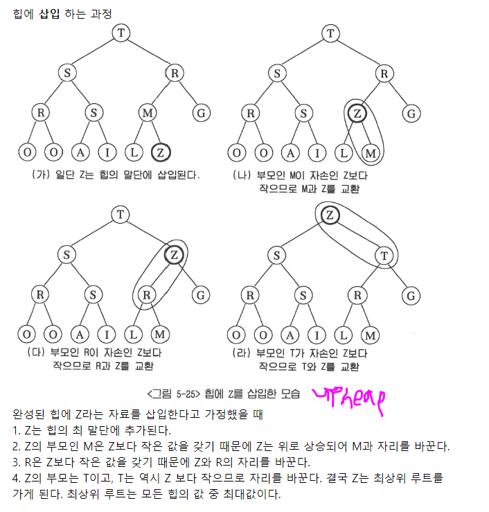

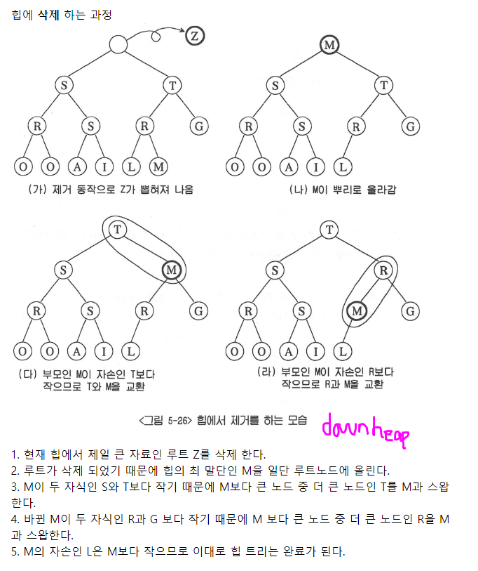

```python
def heap_sort(a):

    def down_heap(a, left:int, right:int):      #루트를 삭제한 힙의 재구성
        temp = a[left]        # 기존 루트
        parent = left

        while parent < (right + 1) // 2: #부모노드는 내부노드, right+1은 총 개수(n)
            cl = parent * 2 + 1     # 자식 중 왼쪽 노드
            cr= cl +1                # 오른쪽 자식
            child = cr if cr<=right and a[cr]> a[cl] else cl
            if temp >= a[child]:
                break
            a[parent] = a[child]
            parent= child               #parent 개수 조절
        a[parent] = temp

    n = len(a)

    # 배열을 힙으로 만들기 (p.293)
    for i in range ( (n-1) //2, -1, -1):       # (n-1)//2 는 리프의 부모노드
        down_heap(a, i , n-1)                   # a[i]~ a[n-1]을 힙으로 만들기

    # 힙인 배열을 정렬하기-> 힙정렬 알고리즘 알아보기 (p. 291)
    for i in range(n-1, 0, -1):
        a[0], a[i]= a[i], a[0]
        down_heap(a, 0, i-1)                   # a[0]~ a[i-1]을 힙으로 만들기





if __name__ == '__main__':
    print("힙 정렬을 수행합니다.")
    num= int(input("원소 수를 입력하세요.: "))
    x = [None] * num                        # 원소 수가 num인 배열 생성

    for i in range(num):
        x[i]= int(input(f'x[{i}]: '))

    heap_sort(x)                                #배열 x를 힙정렬

    print("오름차순으로 정렬했습니다.")
    for i in range(num):
        print(f'x[{i}]= {x[i]}')
```

```
힙 정렬을 수행합니다.
원소 수를 입력하세요.: 10
x[0]: 1
x[1]: 10
x[2]: 5
x[3]: 8
x[4]: 9
x[5]: 2
x[6]: 4
x[7]: 6
x[8]: 7
x[9]: 3
오름차순으로 정렬했습니다.
x[0]= 1
x[1]= 2
x[2]= 3
x[3]= 4
x[4]= 5
x[5]= 6
x[6]= 7
x[7]= 8
x[8]= 9
x[9]= 10
```

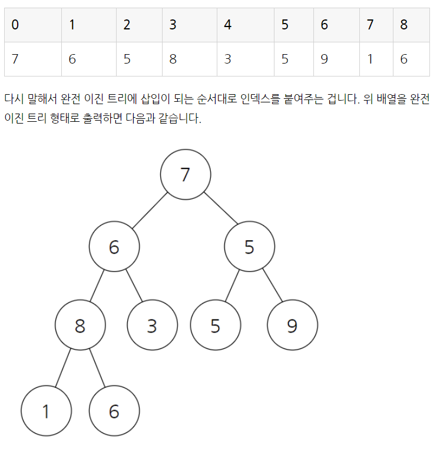

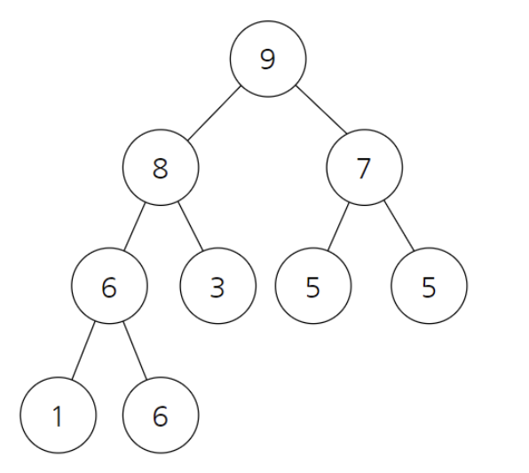

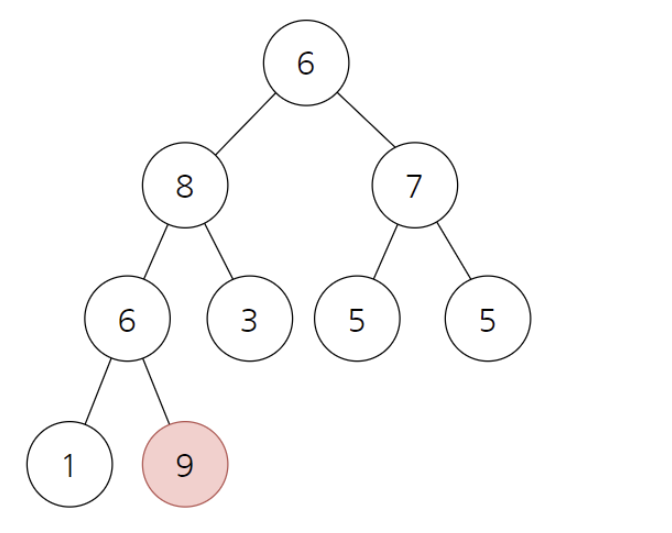

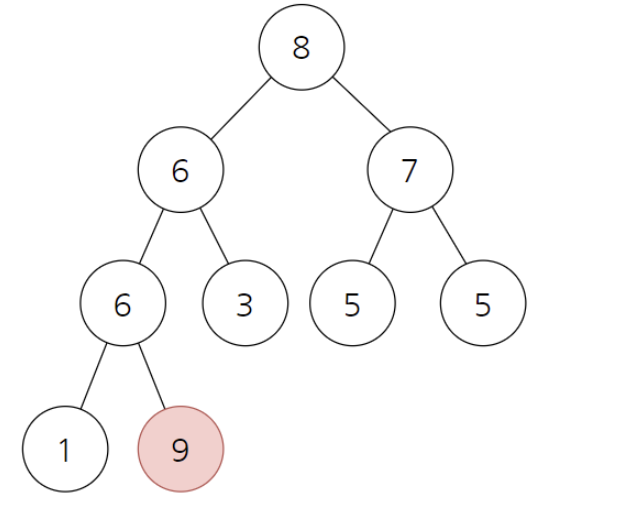

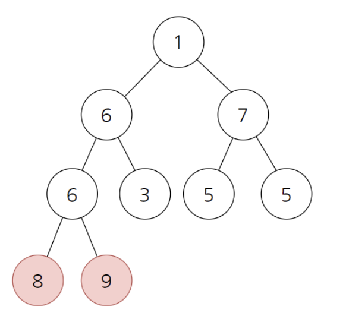

## 힙정렬의 시간복잡도 : O(N * logN)

### 힙 모듈의 함수 활용하기

#### 파이썬의 heapq 모듈은 최소힙으로 구현되어 있음

- heapq.heappush(heap, item) : item을 heap에 추가
- heapq.heappop(heap) : heap에서 가장 작은 원소를 pop & 리턴. 비어 있는 경우 IndexError가 호출됨.
- heapq.heapify(x) : 리스트 x를 즉각적으로 heap으로 변환함 (in linear time, O(N) )

```python
#  heapq 모듈로 힙정렬 구현하기
#  heappush() 함수 : 힙에 원소 추가 /  heappop() 함수 : 힙에서 원소 제거
# 푸시와 팝은 힙의 조건을 유지하며 수행됨

from heapq import *
heap= []
heappush(heap, 4)
heappush(heap, 5)
heappush(heap, 3)
heappush(heap, 2)
heappush(heap, 7)
heappush(heap, 1)
heappush(heap, 9)
heap                         #[1, 3, 2, 5, 7, 4, 9]
heappop(heap)                         #1
heappop(heap)                       #2
heappop(heap)                       #3
heappop(heap)                       #4
heappop(heap)                       #5
heappop(heap)                       #7
heappop(heap)                       #9
```

```
9
```

```python
# 기존 배열을 힙 구조로 바꾸기 : heapify() 함수- 최소힙 형태
from heapq import *

a= [7,6, 5, 8, 3, 5, 9, 1, 6]
heapify(a)
a
```

```
[1, 3, 5, 6, 7, 5, 9, 8, 6]
```

### 힙큐 알고리즘 주석

https://python.flowdas.com/library/heapq.html

https://www.daleseo.com/python-heapq/

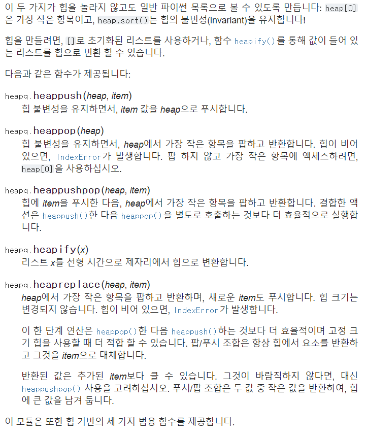